# Ch 12-13 r4ds hw

Chris Sirico

10/6/2017

# R4DS Ch. 12 - 13 Exercises

## 12.2.1

1. **Using prose, describe how the variables and observations are organised in each of the sample tables.**

`table1` Layed out with variables in columns and observations by country in rows.

`table2` This table conflates values of numbers of cases and total population in the same column (`count`) and stores variable data (`cases`/`population`) in the `type` column.

`table3` This table combines the variables of cases and population in the right column, `rate`.

`table4a / table4b` These tables don’t have a column for the variables `cases` and `population`, but rather split them between tables, which makes it harder to calculate rate.

1. **Compute the `rate` for `table2`, and `table4a` + `table4b`. You will need to perform four operations:**
   1. Extract the number of TB cases per country per year.
   2. Extract the matching population per country per year.
   3. Divide cases by population, and multiply by 10000.
   4. Store back in the appropriate place.

```r
#recreate table2
table2 <- tibble(
  country = c("Afghanistan","Afghanistan","Afghanistan","Afghanistan","Brazil","Brazil","Brazil","Brazil","China","China","China","China"),
  year = parse_integer(c(1999,1999,2000,2000,1999,1999,2000,2000,1999,1999,2000,2000)),
  type = c("cases","population","cases","population","cases","population","cases","population","cases","population","cases","population"),
  count = parse_integer(c(745,19987071,2666,20595360,37737,172006362,80488,174504898,212258,1272915272,213766,1280428583)))

#Extract to vectors
country_v <- filter(table2, type == "cases")[["country"]]
year_v <- filter(table2, type == "cases")[["year"]]
count_v <- filter(table2, type == "cases")[["count"]]
pop_v <- filter(table2, type == "population")[["count"]]

# Reconstitute, divide & multiply into tibble
tb2rate <- tibble(country = country_v,
       year = year_v,
       cases = count_v,
       population = pop_v,
       rate = count_v / pop_v * 10000
)
tb2rate %>% print
```

```
## # A tibble: 6 x 5
##       country  year  cases population     rate
##         <chr> <int>  <int>      <int>    <dbl>
## 1 Afghanistan  1999    745   19987071 0.372741
## 2 Afghanistan  2000   2666   20595360 1.294466
## 3      Brazil  1999  37737  172006362 2.193930
## 4      Brazil  2000  80488  174504898 4.612363
## 5       China  1999 212258 1272915272 1.667495
## 6       China  2000 213766 1280428583 1.669488
```

```r
#recreate table4a
table4a <- tibble(
  country = c("Afghanistan","Brazil","China"),
  "1999" = parse_integer(c(745,37737,212258)),
  "2000" = parse_integer(c(2666,80488,213766)))

#recreate table4b
table4b <- tibble(
  country = c("Afghanistan","Brazil","China"),
  "1999" = parse_integer(c(19987071,172006362,1272915272)),
  "2000" = parse_integer(c(20595360,174504898,1280428583)))

countries <- table4a[["country"]]
cases <- c(table4a[["1999"]],table4a[["2000"]])
populations <- c(table4b[["1999"]],table4b[["2000"]])

# hacky way to get three of each year in ascending order into a vector
years <- tibble( year =
  c(
    ((select(table4a, -country) %>% colnames())),
    ((select(table4a, -country) %>% colnames())),
    ((select(table4a, -country) %>% colnames()))
   )
  ) %>%
  arrange(year)
years <- years[[1]]

# years <- select(table4a, -country) %>% colnames()

new_df <- tibble(
  country = c(countries,countries),
  year = years,
  case_num = cases,
  population = populations,
  rate = case_num / population * 10000
)
(new_df)
```

```
## # A tibble: 6 x 5
##       country  year case_num population     rate
##         <chr> <chr>    <int>      <int>    <dbl>
## 1 Afghanistan  1999      745   19987071 0.372741
## 2      Brazil  1999    37737  172006362 2.193930
## 3       China  1999   212258 1272915272 1.667495
## 4 Afghanistan  2000     2666   20595360 1.294466
## 5      Brazil  2000    80488  174504898 4.612363
## 6       China  2000   213766 1280428583 1.669488
```

[output not shown]

**1. Recreate the plot showing change in cases over time using `table2` instead of `table1`. What do you need to do first?**

We need to filter out “population” rows from column `type` so we’re left with only count.

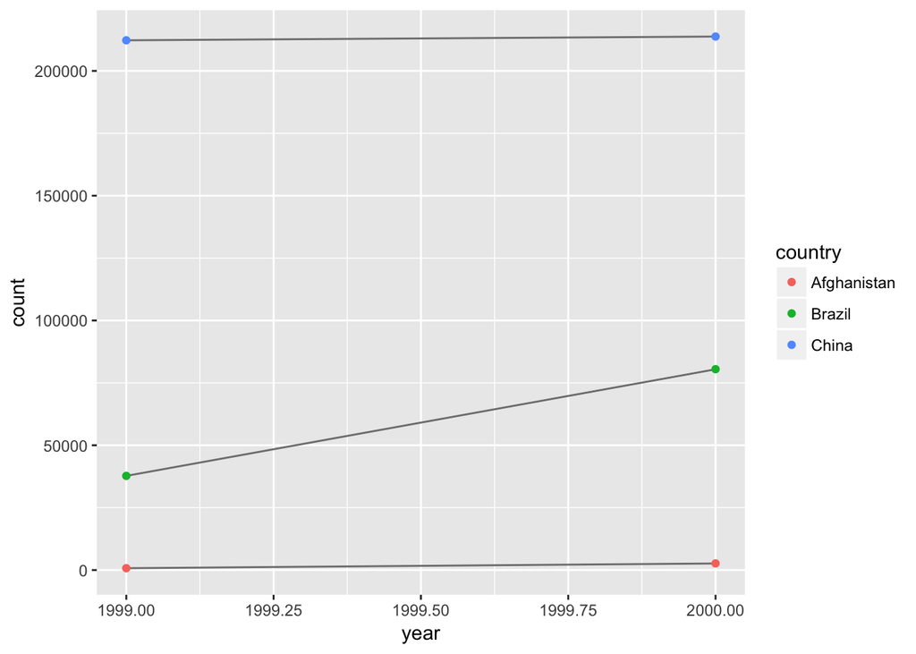

## 12.3.3 Exercises

1. **Why are `gather()` and `spread()` not perfectly symmetrical? Carefully consider the following example:**

```r
    stocks <- tibble(
      year   = c(2015, 2015, 2016, 2016),
      half  = c(   1,    2,     1,    2),
      return = c(1.88, 0.59, 0.92, 0.17)
    )

    stocks %>% print

    stocks %>%
      spread(year, return) %>% print

    stocks %>%
      spread(year, return) %>% # print
      gather("year", "return", `2015`:`2016`) %>% print

    stocks %>%
      spread(year, return) %>% # print
      gather("year", "return", `2015`:`2016`) %>% print
```

[output not shown]

(Hint: look at the variable types and think about column *names*.)

**Both `spread()` and `gather()` have a `convert` argument. What does it do?**

`convert = TRUE` allows `spread` to automatically create variables of a type appropriate to the contents.

1. **Why does this code fail?**

```r
    table4a %>%
      gather(1999, 2000, key = "year", value = "cases")
```

```
## Error in inds_combine(.vars, ind_list): Position must be between 0 and n
```

Years are non-syntactic and must be escaped with backticks.

1. **Why does spreading this tibble fail? How could you add a new column to fix the problem?**

```r
    people <- tribble(
      ~name,             ~key,    ~value,
      #-----------------|--------|------
      "Phillip Woods",   "age",       45,
      "Phillip Woods",   "height",   186,
      "Phillip Woods",   "age",       50,
      "Jessica Cordero", "age",       37,
      "Jessica Cordero", "height",   156
    )

   spread(people, key, value)
```

[output not shown]

There is no differentiating variable for Phillip Woods’ two age observations. We could add a column with the year, an ID or something similar.

1. **Tidy the simple tibble below. Do you need to spread or gather it? What are the variables?**

```r
    preg <- tribble(
      ~pregnant, ~male, ~female,
      "yes",     NA,    10,
      "no",      20,    12
    )

    # Vars are sex, pregnant and count. Needs to be gathered.

    gather(preg, male, female, key = "sex", value = "count")
```

```
## # A tibble: 4 x 3
##   pregnant    sex count
##      <chr>  <chr> <dbl>
## 1      yes   male    NA
## 2       no   male    20
## 3      yes female    10
## 4       no female    12
```

## 12.4.3 Exercises

1. **What do the `extra` and `fill` arguments do in `separate()`? Experiment with the various options for the following two toy datasets.**

   `fill` tells R on which edge of the table to put missing values. `extra` specifies whether extra values are merged into the last cell or dropped.

   ```r
   tibble(x = c("a,b,c", "d,e,f,g,h", "h,i,j")) %>%
     separate(x, c("one", "two", "three"), extra = "merge")
   ```

   ```
   ## # A tibble: 3 x 3
   ##     one   two three
   ## * <chr> <chr> <chr>
   ## 1     a     b     c
   ## 2     d     e f,g,h
   ## 3     h     i     j
   ```

   ```r
   tibble(x = c("a,b,c", "d,e", "f,g,i")) %>%
     separate(x, c("one", "two", "three"), fill = "left", remove = F)
   ```

   ```
   ## # A tibble: 3 x 4
   ##       x   one   two three
   ## * <chr> <chr> <chr> <chr>
   ## 1 a,b,c     a     b     c
   ## 2   d,e  <NA>     d     e
   ## 3 f,g,i     f     g     i
   ```

2. **Both `unite()` and `separate()` have a `remove` argument. What does it do? Why would you set it to `FALSE`?**

   You can preserve the orginal column and split the output to additional columns if you want to munge non-destructively.
3. **Compare and contrast `separate()` and `extract()`. Why are there three variations of separation (by position, by separator, and with groups), but only one unite?**

   Okay, so. Extract grabs just the parts you want, while separate grabs everything except separator characters. It’s necessary to have several ways to split values because there are many ways data can be combined in a column. You only need one function for combining multiple columns, because that separation is explicit in the structure of the data.

```r
library(dplyr)
df <- data.frame(x = c("aoueao-oeu", "a-b", "a-d", "b-c", "d-e"))
df %>% extract(x, "A")
```

```
##        A
## 1 aoueao
## 2      a
## 3      a
## 4      b
## 5      d
```

```r
# ([[:alnum:]]+) seems to be telling the function to look for an alphanumeric character. Seems like it returns NA if it fails to find something that matches exclusively.
df %>% extract(x, c("A", "B"), "([[:alnum:]]+)-([[:alnum:]]+)")
```

```
##        A   B
## 1 aoueao oeu
## 2      a   b
## 3      a   d
## 4      b   c
## 5      d   e
```

```r
# If no match, NA:
df %>% extract(x, c("A", "B"), "([a-d]+)-([a-d]+)")
```

```
##      A    B
## 1 <NA> <NA>
## 2    a    b
## 3    a    d
## 4    b    c
## 5 <NA> <NA>
```

## 12.5.1 Exercises

1. **Compare and contrast the `fill` arguments to `spread()` and `complete()`.**

`fill` takes the dataset and a column and does the rest to get rid of missing values. `complete` takes similar arguments, but makes all missing value combinations explicit. `spread` takes the dataset, a column whose values should become column names, and the column whose values should be spread below the new columns.

1. **What does the direction argument to `fill()` do?** It tells the function whether to pull values `down` or `up` into NA cells. Default is `down`.